# The 2016 Michigan Presidential Primary Election

Vincent Russo

April 21, 2016

## Introduction

On March 8th, 2016, Michigan held the presidential primary for the 2016 presidential election. Famed statistician Nate Silver of the website FiveThirtyEight (Silver 2008) predicted the outcome of the Michigan primary for democratic candidates Bernie Sanders and Hillary Clinton. Silver’s predictions suggested that Hillary would win the democratic primary with a 99% chance of certainty (Silver 2016). This prediction, coming from the same person who accurately predicted the winner of all 50 states (including the District of Columbia) for the 2012 presidential election (Hough 2012), had some significant weight to it. However, despite FiveThirtyEight’s 99% chance for Hillary to win the democratic primary in Michigan, it was won instead by senator Bernie Sanders. Silver was not alone in his prediction, though, in nearly every poll, Hillary was from 10 to 20 points above Bernie Sanders (“Michigan Democratic Presidential Primary” 2016).

What did FiveThirtyEight and the majority of the polls miss for Michigan? Is it possible that this event is simply a fluke and nothing but a blip in the primary polling data? I can’t say that this post really provides an answer to the previous questions. This is more or less a black box analysis of the primary results for Michigan to see if anything really stands out, and is just a fun opportunity to explore some data. As we’ll see, nothing really tends to stand out to answer this question, but by analyzing this data we may set ourselves up for a broader analysis. The content in this post is more exploratory and breadth based.

I’m originally from Michigan and have lived there for most of my life. I have a general sense of the demographic layout of the state, and a rough idea as to how certain counties would cast their vote. Using this and the data, let’s dig in further.

## Data and R Packages

For the data, we will be primarily using the data provided by Kaggle (Hammer 2016) on the primary election. For the analysis, We will be using R, and will explicitly mention any R packages that I use inline in this post. First, we’ll load the appropriate R packages and load in the data from `primary_results.csv` and `county_facts.csv`. The `primary_results.csv` file contains the information for each county in each state, and the distribution of votes that each candidate obtained. The `county_facts.csv` file gives more information on the demographic makeup of each county including race, education, etc. More information on these data sources can be found here (Hammer 2016).

```r
# Import packages
libs <- c("dplyr","DT","GGally","ggplot2","grid","gridExtra","plotly","stargazer","randomForest",
          "readr","rgeos","rgdal","maptools","maps","RColorBrewer","scales")
lapply(libs, require, character.only = TRUE)

# Import data
demographics <- read.csv("../input/county_facts.csv",stringsAsFactors = F)
demographics <- subset(demographics,state_abbreviation !="")
primary <- read.csv("../input/primary_results.csv",stringsAsFactors = F)
```

The data cleaning process is heavily derivative of the process used by Papiu (Papiu 2016) in his Kernel Kaggle submission, which we present here for completeness.

```r
# Place the winners and the fraction of votes won for Democrats and Republicans
# into respective data frames.
dem_votes <- primary %>%
  filter(party == "Democrat") %>%
  group_by(state_abbreviation, county) %>%
  summarize(winner = candidate[which.max(fraction_votes)],
            Vote = max(fraction_votes),
            votes = max(votes))

rep_votes <- primary %>%
  filter(party == "Republican") %>%
  group_by(state_abbreviation, county) %>%
  summarize(winner = candidate[which.max(fraction_votes)],
            Vote = max(fraction_votes),
            votes = max(votes))

# Now, we place in the relevant demographic information.
demographics %<>%
  filter(state_abbreviation %in% c("MI")) %>%
  select(state_abbreviation = state_abbreviation, county = area_name,
         income = INC110213, hispanic = RHI725214,
         black = RHI225214, female = SEX255214, foreign_born = POP645213,
         veteran = VET605213, white = RHI825214, college = EDU685213, density = POP060210) %>%
  mutate(county = gsub(" County", "", county))

# Join by state since some county names overlap.
dem_votes <- inner_join(dem_votes, demographics, by = c("state_abbreviation","county"))
rep_votes <- inner_join(rep_votes, demographics, by = c("state_abbreviation","county"))
total_votes <- rbind(dem_votes, rep_votes)
```

## Exploratory Data Analysis

We now have the data ready to go. First, how many primary elections did each candidate win?

```r
state_name <- "Michigan"

# We'll be using the following hex codes to denote the respective colors for
# each candidate so that we can distinguish them more easily.
sanders_hex <- "#83BC5E"
clinton_hex <- "#0074D3"
trump_hex <- "#D65454"
kasich_hex <- "#3CA0A0"
cruz_hex <- "#EABC3B"

# Sort by total number of wins.
total_votes <- within(total_votes,
                      winner <- factor(winner,
                                       levels = names(sort(table(winner),
                                                           decreasing = TRUE))))
# Total number of Michigan primaries won by candidate.
total_votes %>% count(winner) %>%
  plot_ly(x = winner, y = n, type = "bar", marker = list(color = c(sanders_hex, trump_hex, clinton_hex, kasich_hex, cruz_hex)) ) %>%
  layout(title = "Total Number of Michigan Primaries Won by Candidate",
         xaxis = list(title = "Presidential Candidates"),
         yaxis = list(title = "Total Primaries Won"))
```

[interactive chart not shown]

Let’s also take a look at a map of Michigan that highlights the counties where Bernie Sanders and Hillary Clinton obtained a victory.

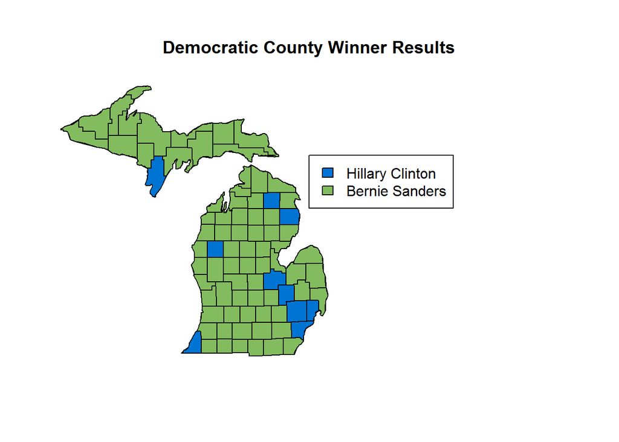

```r
state_name <- "Michigan"
map(database = "county", region = "Michigan", xlim=c(-91, -75))

for (i in 1:nrow(dem_votes)) {
  if (dem_votes$winner[i] == "Bernie Sanders") {
    map("county", paste(state_name, gsub(". ", ".", dem_votes$county[i], fixed = TRUE), sep=","), col=sanders_hex, fill=T, add=T)
  } else {
    map("county", paste(state_name, gsub(". ", ".", dem_votes$county[i], fixed = TRUE), sep=","), col=clinton_hex, fill=T, add=T)
  }
}
title("Democratic County Winner Results")
legend(c("Hillary Clinton","Bernie Sanders"), x = -83, y = 46, horiz = FALSE, fill = c(clinton_hex, sanders_hex))
```

```r
total_votes %>%
  group_by(winner) %>%
  summarize(round(mean(income)),
            round(mean(white),1), round(mean(black),1), round(mean(hispanic),1),
            round(mean(veteran),1), round(mean(foreign_born),1),
            round(mean(college),1),round(mean(density)) ) %>%
  datatable(colnames = c(" ",  "Winner", "Income", "White (non-Hispanic)", "Black", "Hispanic", "Veteran", "Foreign Born","College", "Density (pop/sq m)"),
            class = 'compact', caption = "Average County Demographics by Winner")
```

|  | Winner | Income | White (non-Hispanic) | Black | Hispanic | Veteran | Foreign Born | College | Density (pop/sq m) |
| --- | --- | --- | --- | --- | --- | --- | --- | --- | --- |
| 1 | Bernie Sanders | 43678 | 89.5 | 2.8 | 3.4 | 5202.2 | 2.4 | 19.6 | 114 |
| 2 | Donald Trump | 43044 | 89 | 3.8 | 2.9 | 7644.8 | 2.3 | 18.6 | 176 |
| 3 | Hillary Clinton | 43185 | 79.3 | 13.1 | 3.5 | 29245.2 | 4.4 | 19.5 | 739 |
| 4 | Ted Cruz | 46257 | 85.5 | 3.9 | 7 | 9947.1 | 4.3 | 22.5 | 232 |
| 5 | John Kasich | 52415 | 74.8 | 12.1 | 4.6 | 16132.5 | 8.1 | 42.6 | 467 |

At first glance, there’re a few things that stand out that confirm much of what the popular consensus is on the candidates. For instance, we see Trump’s claim of “loving the poorly educated”(Hafner 2016) paid off since Trump is the candidate whose voters have the poorest education (although, not by much, at least in the state of Michigan). Trump also does the worst with Hispanics among all of the other candidates, which again, isn’t saying anything particularly profound, especially given Trump’s comments on Hispanics(Bran 2015).

Looking at the data in a table is nice, but producing plots will serve us better. To do some candidate by candidate analysis, let’s split the vote data frames in terms of individual candidates. We will be primarily focusing on Clinton, Sanders, and Trump.

```r
sanders <- filter(dem_votes, winner == "Bernie Sanders")
clinton <- filter(dem_votes, winner == "Hillary Clinton")
trump <- filter(rep_votes, winner == "Donald Trump")

clinton_sanders <- rbind(clinton,sanders)
clinton_trump <- rbind(clinton,trump)
sanders_trump <- rbind(sanders,trump)

clinton_sanders_trump <- rbind(clinton_sanders,trump)
```

Now, just so we have a visual component to our already existing intuition on how Trump is with respect to the Hispanic community, let’s plot how he fairs in each county with respect to the populations of Whites vs. Hispanics.

```r
plot_ly(trump, x = white, y = hispanic, mode = "markers", color = winner, colors = trump_hex,
        size = votes, hoverinfo = "text",
        text = paste("State: ", state_abbreviation, "County: ", county, "College: ", college, "Income: ", income)) %>%
  layout(title ="Counties by Percentage of Whites vs. Hispanics for Donald Trump",
         xaxis = list(title = "Percentage of White Population"),
         yaxis = list(title = "Percentage of Hispanic Population"))
```

[interactive chart not shown]

The size of the circle on the graph corresponds to how many total votes Donald Trump received in each county. Also, if you hover over any of the circles, some further information is accessible about the demographics for each county that the circle corresponds to.

Okay, so we have a visual confirmation of what we more or less already knew to be true from both the table and our intuition based on various media sources. For the heck of it, let’s see how Clinton and Sanders fair on this front.

```r
plot_ly(clinton_sanders, x = white, y = hispanic, mode = "markers", color = winner, colors = c(clinton_hex, sanders_hex),
        size = votes, hoverinfo = "text",
        text = paste("State: ", state_abbreviation, "County: ", county, "College: ", college, "Income: ", income)) %>%
  layout(title ="Counties by Percentage of Whites vs. Hispanics for Hillary Clinton and Bernie Sanders",
         xaxis = list(title = "Percentage of White Population"),
         yaxis = list(title = "Percentage of Hispanic Population"))
```

[interactive chart not shown]

Note that you can see just the points corresponding to either Bernie Sanders or Hillary Clinton by clicking either circle in the legend of the plot. One thing that stood out to me was the large circle to the far left of the graph for Hillary Clinton. This circle corresponds to Wayne county, where I used to live, and where the city of Detroit is located in as well. The city of Detroit is known to have a large Black population (at the time of this writing, 84.3% of the population(“List of U.S. Cities with Large African-American Populations” 2016) identifies as Black). Clinton is also known to poll very well in the Black community(Foner 2016). Indeed, this intuition is slightly more solidified by the following plot between Clinton and Sanders that compares White and Black percentages of populations across the counties in Michigan.

```r
plot_ly(clinton_sanders, x = white, y = black, mode = "markers", color = winner, colors = c(clinton_hex, sanders_hex),
        size = votes, hoverinfo = "text",
        text = paste("State: ", state_abbreviation, "County: ", county, "College: ", college, "Income: ", income)) %>%
  layout(title ="Counties by Percentage of Whites vs. Blacks for Hillary Clinton and Bernie Sanders",
         xaxis = list(title = "Percentage of White Population"),
         yaxis = list(title = "Percentage of Black Population"))
```

[interactive chart not shown]

# Some quick and dirty analysis

Based on what we’ve seen thus far from our plots, perhaps we can come up with a rudimentary predictive model based on the demographics. First, let’s create a variable for the candidates Clinton, Sanders, and Trump, where we will be normalizing the number of votes to make our analysis easier.

```r
trump <- primary %>%
  filter(candidate == "Donald Trump")
trump <- inner_join( trump, demographics, by = c("state_abbreviation","county"))

trump$income <- trump$income/1000
trump$fraction_votes <- trump$fraction_votes * 100

clinton <- primary %>%
  filter(candidate == "Hillary Clinton")
clinton <- inner_join( clinton, demographics, by = c("state_abbreviation","county"))

clinton$income <- clinton$income/1000
clinton$fraction_votes <- clinton$fraction_votes * 100

sanders <- primary %>%
  filter(candidate == "Bernie Sanders")
sanders <- inner_join( sanders, demographics, by = c("state_abbreviation","county"))

sanders$income <- sanders$income/1000
sanders$fraction_votes <- sanders$fraction_votes * 100
```

Let’s first do some basic plotting along with a bit of linear regression to start off. The following plots consider each of the three candidates (Clinton, Sanders, and Trump). In each of the following plots, we consider the variable `fraction_votes` as our response and the variable `college` to be the predictor variable.

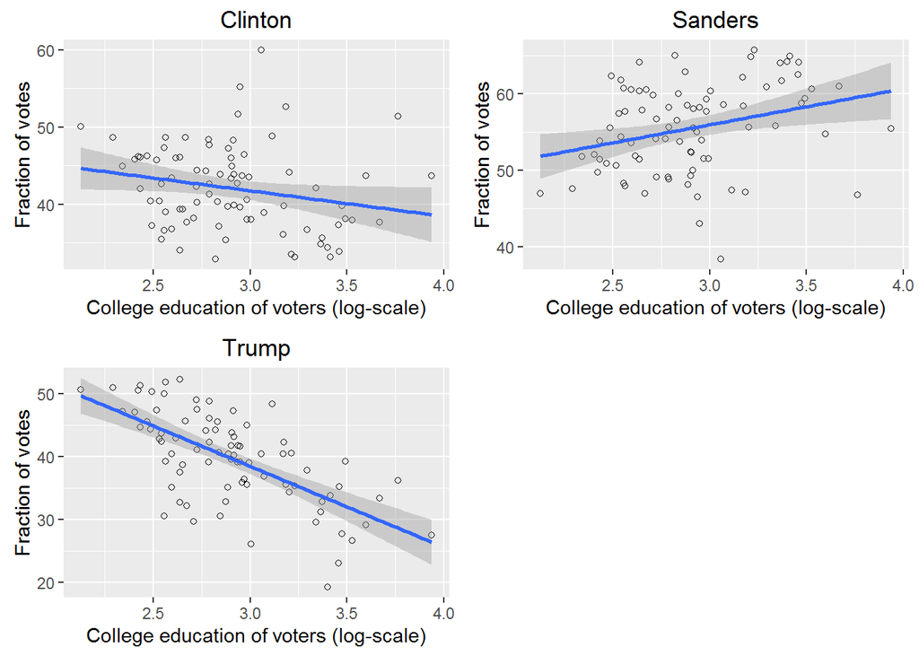

```r
g1 <- ggplot(clinton, aes(x=log(college), y=fraction_votes)) +
  geom_point(shape=1) +      # Use hollow circles
  geom_smooth(method=lm) +   # Add linear regression line
  labs(list(title = "Clinton",
            x = "College education of voters (log-scale)",
            y = "Fraction of votes"))
g2 <- ggplot(sanders, aes(x=log(college), y=fraction_votes)) +
  geom_point(shape=1) +      # Use hollow circles
  geom_smooth(method=lm) +   # Add linear regression line
  labs(list(title = "Sanders",
            x = "College education of voters (log-scale)",
            y = "Fraction of votes"))
g3 <- ggplot(trump, aes(x=log(college), y=fraction_votes)) +
  geom_point(shape=1) +      # Use hollow circles
  geom_smooth(method=lm) +   # Add linear regression line
  labs(list(title = "Trump",
            x = "College education of voters (log-scale)",
            y = "Fraction of votes"))
grid.arrange(g1, g2, g3, nrow =2, ncol = 2)
```

```r
lm_trump.fit = lm(fraction_votes ~ college, data = trump)
summary(lm_trump.fit)
```

```
##
## Call:
## lm(formula = fraction_votes ~ college, data = trump)
##
## Residuals:
##      Min       1Q   Median       3Q      Max
## -14.5844  -3.0068   0.1404   4.1308  10.3017
##
## Coefficients:
##             Estimate Std. Error t value Pr(>|t|)
## (Intercept) 50.73998    1.63447  31.044  < 2e-16 ***
## college     -0.56185    0.07727  -7.272 2.01e-10 ***
## ---
## Signif. codes:  0 '***' 0.001 '**' 0.01 '*' 0.05 '.' 0.1 ' ' 1
##
## Residual standard error: 5.654 on 81 degrees of freedom
## Multiple R-squared:  0.395,  Adjusted R-squared:  0.3875
## F-statistic: 52.88 on 1 and 81 DF,  p-value: 2.006e-10
```

It seems that the $p$-value is low enough to possibly be significant, but we would ideally like to through in some other predictors since we have them available to us from our data set.

$$\color{orange}{\sf fraction\_votes}\color{black} = \beta_{0} + \beta_{1} \times \color{orange}{\sf college}\color{black} + \beta_{2} \times \color{orange}{\sf white}\color{black} + \beta_{3} \times \color{orange}{\sf hispanic}\color{black} + \beta_{4} \times \color{orange}{\sf income}\color{black} + \beta_{5} \times \color{orange}{\sf density}\color{black} + \epsilon,$$
where we represent the regression coefficients as $\beta_0, \beta_1, \cdots, \beta_p$ where $p$ is the total number of predictors. Again, using R, we may compute the multiple linear regression in the following way.

```r
lm_trump.fit = lm(fraction_votes ~ college + white + hispanic + income + density, data = trump)
summary(lm_trump.fit)
```

```
##
## Call:
## lm(formula = fraction_votes ~ college + white + hispanic + income +
##     density, data = trump)
##
## Residuals:
##     Min      1Q  Median      3Q     Max
## -8.2482 -2.7052 -0.2826  3.2585  7.7221
##
## Coefficients:
##              Estimate Std. Error t value Pr(>|t|)
## (Intercept) 51.582441   7.504576   6.873 1.44e-09 ***
## college     -0.456920   0.084666  -5.397 7.25e-07 ***
## white        0.056974   0.080875   0.704   0.4833
## hispanic    -1.456310   0.218985  -6.650 3.79e-09 ***
## income      -0.085561   0.091943  -0.931   0.3550
## density      0.003907   0.001576   2.480   0.0153 *
## ---
## Signif. codes:  0 '***' 0.001 '**' 0.01 '*' 0.05 '.' 0.1 ' ' 1
##
## Residual standard error: 4.224 on 77 degrees of freedom
## Multiple R-squared:  0.6789, Adjusted R-squared:  0.658
## F-statistic: 32.56 on 5 and 77 DF,  p-value: < 2.2e-16
```

# Conclusion

All in all, we had an opportunity to play around with some data and swiftly generate some analysis to give us a lay of the land. I think the question as to how Sanders pulled a victory when he was projected by many to not is still not really clearly answered here. What may make sense is to take a look at the data from all primary elections. Indeed, the data that we have used in this post includes data for all the primaries. Furthermore, one could also obtain data from other sources as well to enhance the data we reviewed in this post.

Another possible avenue to investigate how big of an advantage Sanders has in states that have open elections. That is to say, a primary election is closed if the voters are required to be registered under the party that they are voting under. It is no secret that Sanders tends to do better when independents are allowed in the primaries to vote. The Michigan primaries are thankfully open, as all polls should be, but in many states, this is not the case.

# Acknowledgements

Thanks are due to both Alex Papiu and Joshua Ellis who also have made some excellent assessments on this data, and which some of this code in this script is directly taken from. Thank you both.

# References

Bran, Anna. 2015. “Donald Trump: I Would Force Mexico to Build Border Wall.” MSNBC. http://www.msnbc.com/msnbc/donald-trump-i-would-force-mexico-build-border-wall.

Foner, Eric. 2016. “African-American Voters Have an Understandable Reason to Support Hillary Clinton.” The Nation. https://www.thenation.com/article/african-american-voters-have-a-good-reason-to-support-hillary-clinton/.

Hafner, Josh. 2016. “Donald Trump Loves the ’Poorly Educated’ — and They Love Him.” USA Today. http://www.usatoday.com/story/news/politics/onpolitics/2016/02/24/donald-trump-nevada-poorly-educated/80860078/.

Hammer, Ben. 2016. “2016 Primary Election Data.” Kaggle. https://www.kaggle.com/benhamner/2016-us-election.

Hough, Andrew. 2012. “Nate Silver: Politics ’Geek’ Hailed for Barack Obama Wins US Election Forecast.” The Telegragh. November. http://www.telegraph.co.uk/news/worldnews/us-election/9662363/Nate-Silver-politics-geek-hailed-for-Barack-Obama-wins-US-election-forecast.html.

“List of U.S. Cities with Large African-American Populations.” 2016. Wikipedia. https://en.wikipedia.org/wiki/List_of_U.S._cities_with_large_African-American_populations.

“Michigan Democratic Presidential Primary.” 2016. Real Clear Politics. March. http://www.realclearpolitics.com/epolls/2016/president/mi/michigan_democratic_presidential_primary-5224.html.

Papiu, Alexandru. 2016. “Predictions in the Republican Primary.” Kaggle. https://www.kaggle.com/apapiu/d/benhamner/2016-us-election/predictions-in-the-republican-primary.

Silver, Nate. 2008. “FiveThirtyEight.” FiveThirtyEight. March. http://fivethirtyeight.com/.

———. 2016. “2016 Michigan Democratic Primary Forecast.” FiveThirtyEight. March. http://projects.fivethirtyeight.com/election-2016/primary-forecast/michigan-democratic/.